# Kākā SSF data preparation

Author

Scott Forrest

Here we are preparing GPS data of kākā at Orokonui Ecosanctuary for use in individual-level and population-level step selection functions. We will be using the `amt` package to prepare the data for fitting the step selection functions (Signer, Fieberg, and Avgar 2019).

# Load Packages

```r
library(tidyverse)
packages <- c("amt", "lubridate", "raster", "terra", "Rfast", "beepr", "tictoc")
walk(packages, require, character.only = T)
```

# Import kākā data files

We also remove a couple obvious errors. The majority of erroneous locations were removed with the Shimada et al 2012 speed filter, but we’ve hard-coded a couple of additional errors to remove.

```r
T05 <- read_csv("data/CSV input data - dd_speed_6/T45505_dd_speed_6.csv") %>% filter(...1 != 1448)
T06 <- read_csv("data/CSV input data - dd_speed_6/T45506_dd_speed_6.csv") %>% mutate(id = 45506)
T07 <- read_csv("data/CSV input data - dd_speed_6/T45507_dd_speed_6.csv") %>% mutate(id = 45507)
T08 <- read_csv("data/CSV input data - dd_speed_6/T45508_dd_speed_6.csv") %>% mutate(id = 45508)
T09 <- read_csv("data/CSV input data - dd_speed_6/T45509_dd_speed_6.csv") %>% mutate(id = 45509)
T10 <- read_csv("data/CSV input data - dd_speed_6/T45510_dd_speed_6.csv") %>% mutate(id = 45510)
T11 <- read_csv("data/CSV input data - dd_speed_6/T45511_dd_speed_6.csv") %>% mutate(id = 45511)
T12 <- read_csv("data/CSV input data - dd_speed_6/T45512_dd_speed_6.csv") %>% mutate(id = 45512) %>% filter(...1 != 186)
T13 <- read_csv("data/CSV input data - dd_speed_6/T45513_dd_speed_6.csv") %>% mutate(id = 45513)
T14 <- read_csv("data/CSV input data - dd_speed_6/T45514_dd_speed_6.csv") %>% mutate(id = 45514)
```

# Prepare data for step selection functions

The GPS device T05 had a sampling interval of mostly 2 hours, rather than 3 for the other tags, so we will create a track object with T05 first and them combine with the other data after.

There were also 15-minute locations for all tags, although for step selection functions it is best to have regularly sampled data, so we will remove those for these analyses.

We will be using the `amt` package to prepare the data for fitting the step selection functions (Signer, Fieberg, and Avgar 2019).

The `steps` function will suggest that we create a `steps_by_burst` object. A `steps_by_burst` object keeps only the ‘bursts’ when there are more than 3 regular locations in a row, and calculates the step lengths and turning angles for these bursts. This will be more important we are particularly interesting in the movement dynamics (and have regular data), but in our case we want to keep as much data as possible for the habitat selection parameters, so we’ll keep all of the data by using a simpler `steps` object. This will mean that we will be calculating step lengths and turning angles for when our time intervals between GPS fixes are longer than 2 (for tag T05) or 3 hours (for the other tags).

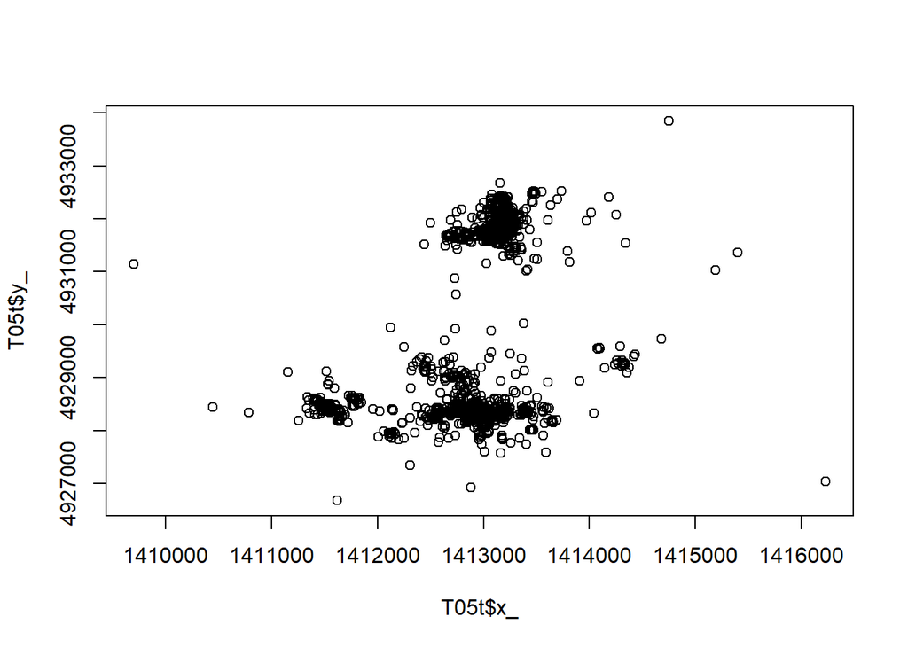

```r
# make an amt track object and project to NZTM
T05t <- T05 %>% make_track(lon, lat, DateTime, crs = 4326) %>%
  transform_coords(crs_to = 2193)

# quick check that the data looks ok
plot(T05t$x_, T05t$y_)
```

```r
# get a summary of the GPS sampling intervals
summarize_sampling_rate(T05t)
```

```
# A tibble: 1 × 9
    min    q1 median  mean    q3   max    sd     n unit
  <dbl> <dbl>  <dbl> <dbl> <dbl> <dbl> <dbl> <int> <chr>
1 0.249  2.00   2.00  1.96  2.00  10.0  1.07  1721 hour
```

```r
# regularise the track to 2 hour intervals and create a steps object
# a steps object has step lengths (sl_) and turning angles (ta_)
T05_steps <- T05t %>%
  track_resample(rate = hours(2), tolerance = minutes(10)) %>%
  steps()
# have a look at the data
head(T05_steps)
```

```
# A tibble: 6 × 10
       x1_      x2_      y1_    y2_   sl_ direction_p    ta_ t1_
*    <dbl>    <dbl>    <dbl>  <dbl> <dbl>       <dbl>  <dbl> <dttm>
1 1413277. 1413117. 4931924. 4.93e6 288.        -2.16 NA     2020-09-23 02:00:07
2 1413117. 1413222. 4931685. 4.93e6 681.         1.42 -2.71  2020-09-23 04:00:08
3 1413222. 1413301. 4932357. 4.93e6 887.        -1.48 -2.90  2020-09-23 06:00:07
4 1413301. 1413309. 4931474. 4.93e6  15.4       -1.01  0.469 2020-09-23 08:00:08
5 1413309. 1413304. 4931460. 4.93e6  15.4       -1.90 -0.889 2020-09-23 12:00:03
6 1413304. 1413292. 4931446. 4.93e6  16.9        2.36 -2.02  2020-09-23 14:00:04
# ℹ 2 more variables: t2_ <dttm>, dt_ <drtn>
```

Now we follow the same process for the other 9 GPS devices.

```r
# combine the data frames
T_all <- rbind(T06, T07, T08, T09, T10, T11, T12, T13, T14)
```

We then nest the data by ID, which makes it straightforward to run the same function over all the IDs.

```r
# nest by id
dat_all <- T_all %>% nest(data = -id)

# add a variable for the sex of the kākā
dat_all$sex <- c("m", "m", "f", "f", "f", "f", "m", "m", "f")

# now we have a list-column where each row contains a dataset
head(dat_all)
```

```
# A tibble: 6 × 3
     id data                  sex
  <dbl> <list>                <chr>
1 45506 <tibble [986 × 14]>   m
2 45507 <tibble [1,112 × 14]> m
3 45508 <tibble [1,253 × 14]> f
4 45509 <tibble [721 × 14]>   f
5 45510 <tibble [818 × 14]>   f
6 45511 <tibble [912 × 14]>   f
```

Now that we have nested data, we can ‘map’ a function over each dataset.

First we create `track` objects.

```r
# create a new list-column that contains `track` objects
dat_all <- dat_all %>%
  mutate(trk = map(data, function(d) {
    make_track(d, lon, lat, DateTime, crs = 4326) %>% transform_coords(crs_to = 2193)
  }))

head(dat_all)
```

```
# A tibble: 6 × 4
     id data                  sex   trk
  <dbl> <list>                <chr> <list>
1 45506 <tibble [986 × 14]>   m     <trck_xyt [986 × 3]>
2 45507 <tibble [1,112 × 14]> m     <trck_xyt [1,112 × 3]>
3 45508 <tibble [1,253 × 14]> f     <trck_xyt [1,253 × 3]>
4 45509 <tibble [721 × 14]>   f     <trck_xyt [721 × 3]>
5 45510 <tibble [818 × 14]>   f     <trck_xyt [818 × 3]>
6 45511 <tibble [912 × 14]>   f     <trck_xyt [912 × 3]>
```

And then we regularise the track to 3-hour intervals, which we use to create `steps` objects.

```r
# create new list-columns that contains cleaned data objects (`dat_clean`) and `steps` objects
dat_all <- dat_all %>%
  mutate(dat_clean = map(trk,
                         ~ {.x %>% track_resample(rate = hours(3), tolerance = minutes(10))}),
         stps = map(dat_clean, ~ .x %>% steps()))
head(dat_all)
```

```
# A tibble: 6 × 6
     id data                  sex   trk                    dat_clean  stps
  <dbl> <list>                <chr> <list>                 <list>     <list>
1 45506 <tibble [986 × 14]>   m     <trck_xyt [986 × 3]>   <trck_xyt> <stps_xyt>
2 45507 <tibble [1,112 × 14]> m     <trck_xyt [1,112 × 3]> <trck_xyt> <stps_xyt>
3 45508 <tibble [1,253 × 14]> f     <trck_xyt [1,253 × 3]> <trck_xyt> <stps_xyt>
4 45509 <tibble [721 × 14]>   f     <trck_xyt [721 × 3]>   <trck_xyt> <stps_xyt>
5 45510 <tibble [818 × 14]>   f     <trck_xyt [818 × 3]>   <trck_xyt> <stps_xyt>
6 45511 <tibble [912 × 14]>   f     <trck_xyt [912 × 3]>   <trck_xyt> <stps_xyt>
```

We can now `unnest` the `steps` objects into a data frame it the T05 steps.

```r
# we name it knowing that we haven't added T05 yet
steps_no05 <- dat_all %>%
  dplyr::select(id, stps) %>% unnest(cols = c(id, stps))
```

Combine all the data together.

```r
# we also add an ID column to the T05 steps
steps_all <- rbind(tibble(id = 45505, T05_steps), steps_no05)
```

# Import the spatial covariates

We are only using a single covariate, which is a categorical layer of habitat in the Dunedin area.

The section in the Methods of the paper regarding the environmental covariate reads:

We used land cover categories from the broad classification of a vegetation map of the wider Dunedin area created by the Dunedin City Council, and functionally similar land cover types were combined. Thus, the podocarp/broadleaf forest category, and the broadleaf category were combined into a single native forest category, and mānuka (*Leptospermum scoparium*) was integrated with kānuka (*Kunzea ericoides*). Small patches of discrete land cover that did not fit into the above categories, such as wetland, beaches, gorse, broom, tussock and exposed rocky surfaces, classified into a single category named ‘other’, as they were not considered relevant resources for kākā, and comprised a small proportion of the landscape. Water bodies were considered non-habitat. Thus, the resulting land cover categories used the analyses were native forest (predominately podocarp and broadleaf), kānuka/mānuka (hereafter denoted kānuka), exotic conifers, exotic hardwoods, agriculture, suburban and other.

Import the layer

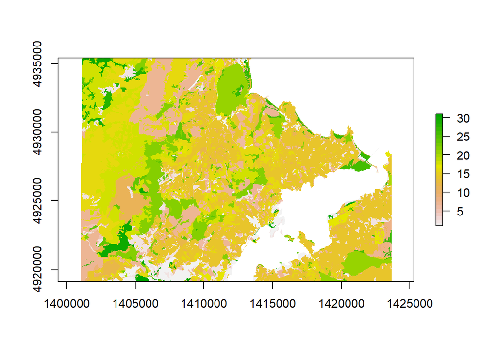

```r
DCChab <- raster("mapping/DCC BCNadj and LCDB.tif")
plot(DCChab, col = terrain.colors(n = 31, rev = T))
```

Reclassify the layer to match the simplified categories in the paper.

We need to specify what values of the original raster will be reclassified to what values in the new raster. This is done by creating a matrix with two columns, the first column is the original values, and the second column is the new values.

```r
rcl <- cbind(c(
  # becomes kanuka catoegory
  15,16,18,
  # becomes native forest category
  22,2,3,24,
  # becomes exotic conifers category
  7,
  # becomes exotic hardwoods category
  5,6,20,
  # becomes agriculture category
  14,
  # becomes suburban category
  1,31,
  # becomes other category
  4,8,9,10,11,13,17,19,23,25,26,27,28,29,30,12,
  # becomes water category
  0,21),

  # these will be the new values of the above categories
  c(1,1,1,
    2,2,2,2,
    3,
    4,4,4,
    5,
    6,6,
    7,7,7,7,7,7,7,7,7,7,7,7,7,7,7,7,
    8,8))

rcl
```

```
      [,1] [,2]
 [1,]   15    1
 [2,]   16    1
 [3,]   18    1
 [4,]   22    2
 [5,]    2    2
 [6,]    3    2
 [7,]   24    2
 [8,]    7    3
 [9,]    5    4
[10,]    6    4
[11,]   20    4
[12,]   14    5
[13,]    1    6
[14,]   31    6
```

[output cut: 18 more lines]

Reclassify the raster.

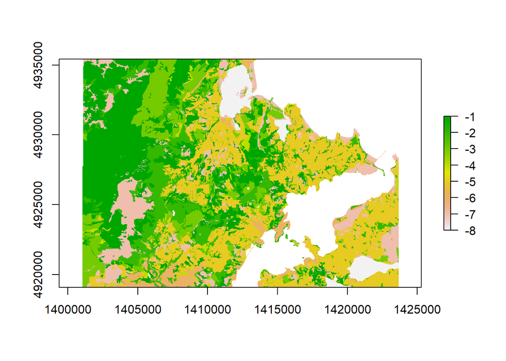

```r
DCC <- reclassify(DCChab, rcl, right = NA)
plot(-DCC)
```

```r
names(DCC) <- "habs"
```

## Creating dummy variables

When fitting the population model with `INLA`, we require ‘dummy variables’, where each habitat category is its own raster with 1s and 0s, rather than a single raster for all habitat categories with e.g. 1-8, like we have above.

### Kānuka (which also contains mānuka)

Here we call kānuka and mānuka dominant forest ‘scrub’ to combine them, although both of these trees can form a variety of bush and forest types.

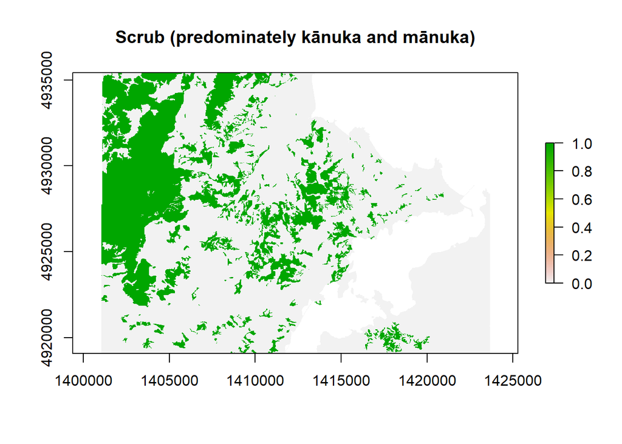

```r
scrub <- DCC == 1
names(scrub) <- "scrub"
plot(scrub, main = "Scrub (predominately kānuka and mānuka)")
```

```r
# calculate the area covered by the category (with 25x25m cells)
paste0("Area of scrub for this extent is ",
       round((cellStats(scrub, stat = sum) * 25 * 25) / 1e6, 2),
       " km^2")
```

```
[1] "Area of scrub for this extent is 77.67 km^2"
```

```r
writeRaster(scrub, "mapping/scrub.tif", overwrite = TRUE)
```

### Native forest

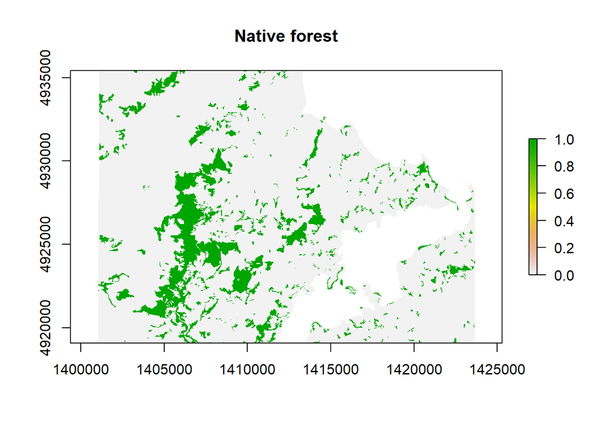

```r
native_forest <- DCC == 2
names(native_forest) <- "native_forest"
plot(native_forest, main = "Native forest")
```

```r
# calculate the area covered by the category (with 25x25m cells)
paste0("Area of native forest for this extent is ",
       round((cellStats(native_forest, stat = sum) * 25 * 25) / 1e6, 2),
       " km^2")
```

```
[1] "Area of native forest for this extent is 35.15 km^2"
```

```r
writeRaster(native_forest, "mapping/native_forest.tif", overwrite = TRUE)
```

### Exotic conifers

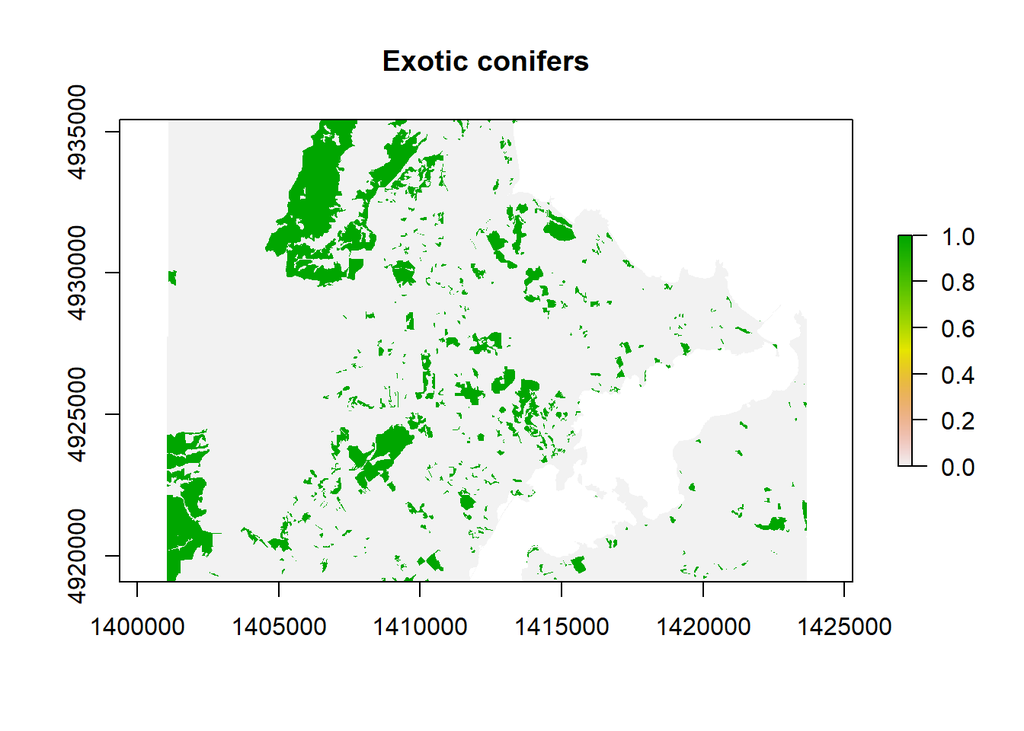

```r
exotic_conifers <- DCC == 3
names(exotic_conifers) <- "exotic_conifers"
plot(exotic_conifers, main = "Exotic conifers")
```

```r
# calculate the area covered by the category (with 25x25m cells)
paste0("Area of native forest for this extent is ",
       round((cellStats(exotic_conifers, stat = sum) * 25 * 25) / 1e6, 2),
       " km^2")
```

```
[1] "Area of native forest for this extent is 33.48 km^2"
```

```r
writeRaster(exotic_conifers, "mapping/exotic_conifers.tif", overwrite = TRUE)
```

### Exotic hardwoods

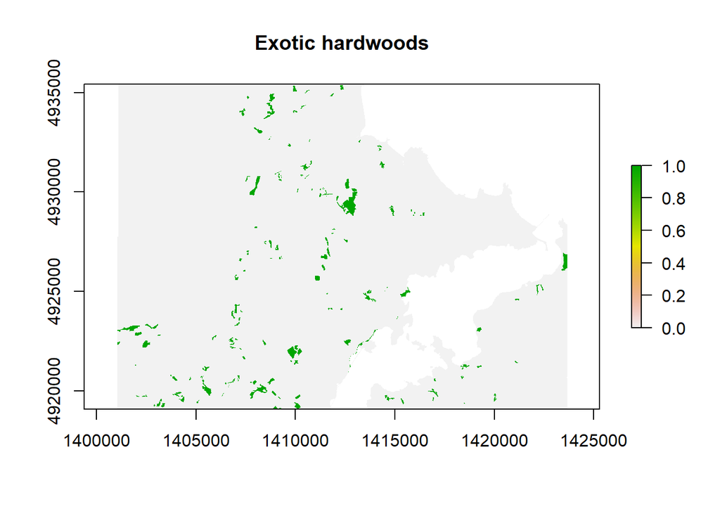

```r
exotic_hardwoods <- DCC == 4
names(exotic_hardwoods) <- "exotic_hardwoods"
plot(exotic_hardwoods, main = "Exotic hardwoods")
```

```r
# calculate the area covered by the category (with 25x25m cells)
paste0("Area of native forest for this extent is ",
       round((cellStats(exotic_hardwoods, stat = sum) * 25 * 25) / 1e6, 2),
       " km^2")
```

```
[1] "Area of native forest for this extent is 4.43 km^2"
```

```r
writeRaster(exotic_hardwoods, "mapping/exotic_hardwoods.tif", overwrite = TRUE)
```

### Agriculture

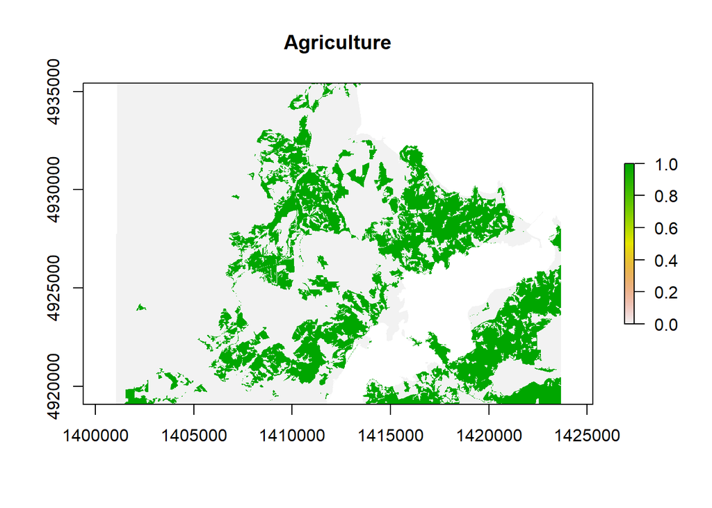

```r
agriculture <- DCC == 5
names(agriculture) <- "agriculture"
plot(agriculture, main = "Agriculture")
```

```r
# calculate the area covered by the category (with 25x25m cells)
paste0("Area of native forest for this extent is ",
       round((cellStats(agriculture, stat = sum) * 25 * 25) / 1e6, 2),
       " km^2")
```

```
[1] "Area of native forest for this extent is 76.83 km^2"
```

```r
writeRaster(agriculture, "mapping/agriculture.tif", overwrite = TRUE)
```

### Suburban

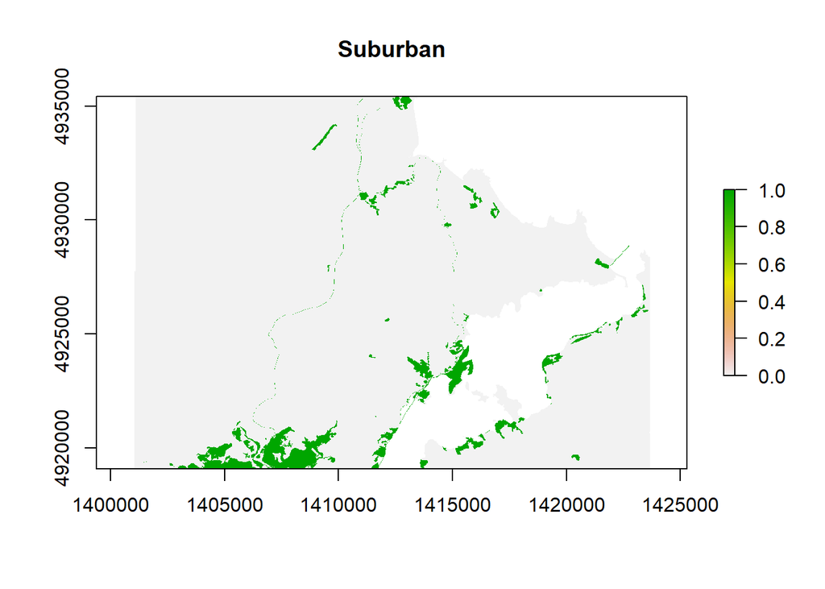

```r
suburban <- DCC == 6
names(suburban) <- "suburban"
plot(suburban, main = "Suburban")
```

```r
# calculate the area covered by the category (with 25x25m cells)
paste0("Area of native forest for this extent is ",
       round((cellStats(suburban, stat = sum) * 25 * 25) / 1e6, 2),
       " km^2")
```

```
[1] "Area of native forest for this extent is 10.8 km^2"
```

```r
writeRaster(suburban, "mapping/suburban.tif", overwrite = TRUE)
```

### Other

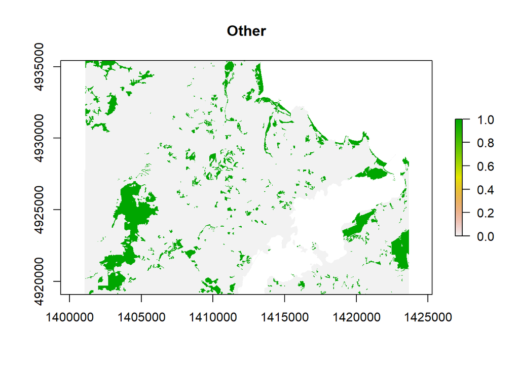

```r
other <- DCC == 7
names(other) <- "other"
plot(other, main = "Other")
```

```r
# calculate the area covered by the category (with 25x25m cells)
paste0("Area of native forest for this extent is ",
       round((cellStats(other, stat = sum) * 25 * 25) / 1e6, 2),
       " km^2")
```

```
[1] "Area of native forest for this extent is 31.82 km^2"
```

```r
writeRaster(other, "mapping/other.tif", overwrite = TRUE)
```

### Water

The areas in the sea are `NA`.

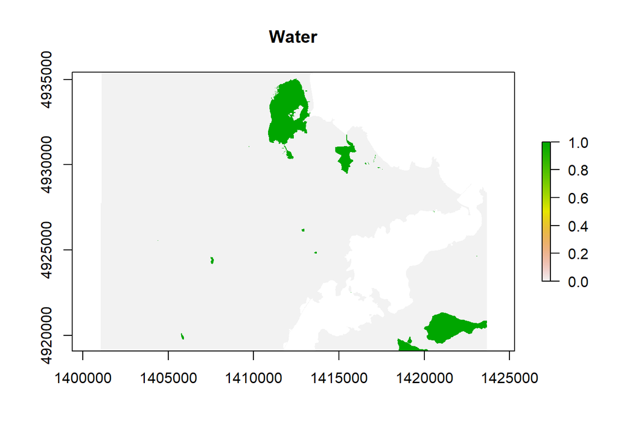

```r
water <- DCC == 8
names(water) <- "water"
plot(water, main = "Water")
```

```r
# calculate the area covered by the category (with 25x25m cells)
paste0("Area of native forest for this extent is ",
       round((cellStats(water, stat = sum) * 25 * 25) / 1e6, 2),
       " km^2")
```

```
[1] "Area of native forest for this extent is 11.97 km^2"
```

```r
writeRaster(water, "mapping/water.tif", overwrite = TRUE)
```

Create a stack of all the rasters so we can sample from them

```r
all_rasters <- raster::stack(DCC,
                             scrub,
                             native_forest,
                             exotic_conifers,
                             exotic_hardwoods,
                             agriculture,
                             suburban,
                             other,
                             water)
```

# Random step sampling

To fit step selection functions we need randomly sampled steps to compare against (which serves to numerically approximate the integral in the step selection function, see Michelot et al. (2024) for more information).

Firstly we want to fit a Gamma distribution to the step lengths, which we can then use to sample random steps. We also want to store the parameters of the ‘tentative’ Gamma distribution to ‘update’ the movement parameters for the predictions after model fitting.

As we will be fitting a population-level model and updating the movement parameters at the population-level, we want to fit the Gamma distribution to all the steps.

```r
tentative_gamma_all <- fit_distr(steps_all$sl_, "gamma")
```

```
Steps with length 0 are present. This will lead to an error when fitting a gamma distribution. 0 step lengths are replaced with the smallest non zero step length, which is: 0.777745206521818
```

```r
tentative_gamma_all
```

```
$name
[1] "gamma"

$params
$params$shape
[1] 0.6789583

$params$scale
[1] 797.1647


$vcov
             scale         shape
scale 192.60612607 -8.120319e-02
shape  -0.08120319  6.911367e-05

attr(,"class")
[1] "gamma_distr" "sl_distr"    "amt_distr"   "list"
```

```r
# store the parameters of the tentative Gamma distribution
tentative_gamma_shape <- tentative_gamma_all$params$shape
tentative_gamma_scale <- tentative_gamma_all$params$scale
```

When we combined the steps dataframe of T05 with the rest of the individuals, we changed the class of the object to a tibble, so we can assign it back to a `steps_xyt` object to sample the random steps.

We only do this because we know it is already in the format of a `steps_xyt` object.

```r
# check the class of the steps objects before we combined the data
class(T05_steps)
```

```
[1] "steps_xyt"  "steps_xy"   "tbl_df"     "tbl"        "data.frame"
```

```r
# check the class of all the data combined
class(steps_all)
```

```
[1] "tbl_df"     "tbl"        "data.frame"
```

```r
# assign the class back to steps_xyt
class(steps_all) <- class(T05_steps)
```

We want to estimate the random steps for each individual, so we nest the data frame by `id` and then use `map` to estimate the random steps for each individual, and extract the covariates.

An important point is that we are using the population-level parameters of the Gamma distribution, and uniform turning angles.

```r
ssf_data_all <- steps_all %>% nest(stps = -id) %>%
  mutate(steps_covs =
           map(stps, ~ .x %>%

                 # sample the random steps from the population-level parameters
                 random_steps(n = 30,
                              rand_sl =
                                random_numbers(tentative_gamma_all,
                                               n = 1e+05),
                              rand_ta =
                                random_numbers(make_unif_distr(),
                                               n = 1e+05)) %>%

                 # extract values from the rasters
                 extract_covariates(all_rasters))) %>%

  # unnest the data frame
  dplyr::select(id, steps_covs) %>% unnest(c(id, steps_covs)) %>%

  # take the log of the step lengths and cosine of the turning angle, which will be used in the model fitting
  mutate(
    y = as.numeric(case_),
    cos_ta_ = cos(ta_),
    log_sl_ = log(sl_))
```

```
Steps with length 0 are present. This will lead to an error when fitting a gamma distribution. 0 step lengths are replaced with the smallest non zero step length, which is: 1.11149474386579
```

```
Steps with length 0 are present. This will lead to an error when fitting a gamma distribution. 0 step lengths are replaced with the smallest non zero step length, which is: 3.30368458716561
```

```
Steps with length 0 are present. This will lead to an error when fitting a gamma distribution. 0 step lengths are replaced with the smallest non zero step length, which is: 1.55559840750248
```

As water is considered non-habitat, we want to filter out the steps that are in the water, and then ensure that each step is paired with an equal number of random steps, which we will set to 10.

```r
# filter out the steps in the water, which includes when the DCC layer in NA, which is the sea
ssf_data_all <- ssf_data_all %>% filter(water != 1 & !is.na(habs))

# grouping works best when it's a tibble object
ssf_data_all_tbl <- as_tibble(ssf_data_all)

# count the number of steps for each individual and step
# we can see that many steps have less than 31 (1 used step + 30 random steps)
ssf_data_all_tbl %>% dplyr::group_by(id, step_id_) %>% dplyr::summarise(n=n())
```

[output not shown]

```
# A tibble: 9,626 × 3
# Groups:   id [10]
      id step_id_     n
   <dbl>    <dbl> <int>
 1 45505        3    28
 2 45505        4    22
 3 45505        5    30
 4 45505        6    30
 5 45505        7    30
 6 45505        8    30
 7 45505        9    27
 8 45505       10    31
 9 45505       11    25
10 45505       12    29
# ℹ 9,616 more rows
```

```r
# only keep 10 random points per used point
ssf_data_all <- ssf_data_all_tbl %>% dplyr::group_by(id, step_id_) %>% dplyr::slice_head(n = 11)
```

Plot to check if the water filtering worked.

There is one location out in the sea, but that shouldn’t effect the analyses.

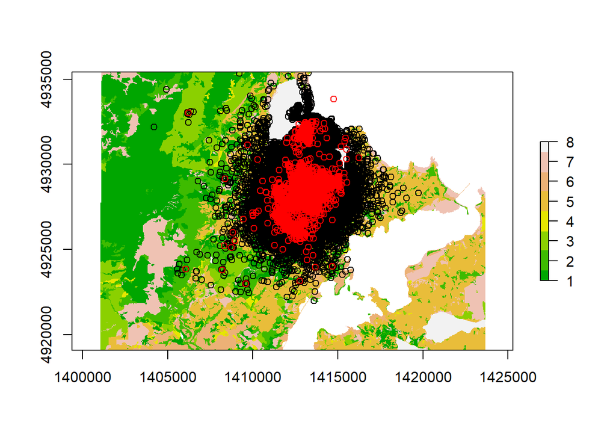

```r
plot(DCC, col = terrain.colors(n = 8))
points(ssf_data_all$x2_, ssf_data_all$y2_)
points(ssf_data_all$x1_, ssf_data_all$y1_, col = "red")
```

### Check the used and random step length and turning angle distributions

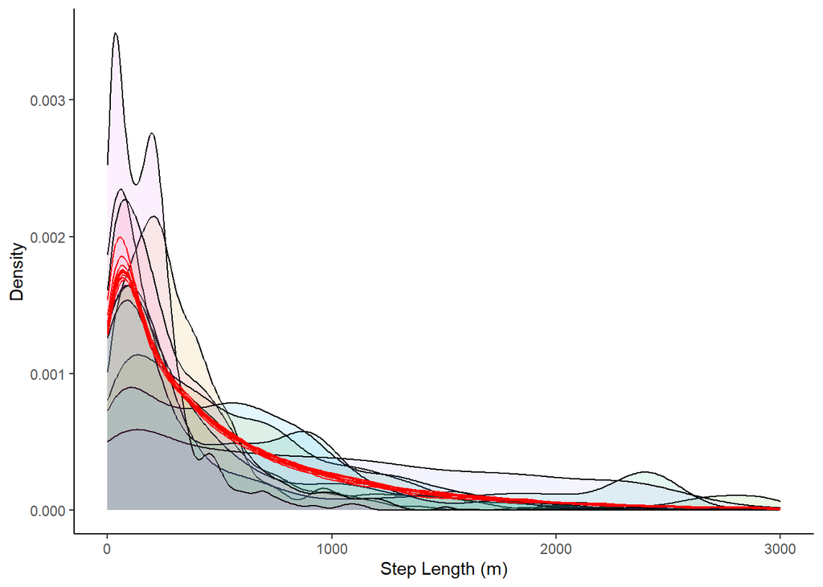

```r
ssf_data_all$idf <- as.factor(ssf_data_all$id)

ggplot() +
  geom_density(data = ssf_data_all %>% filter(y == 1),
               aes(x = sl_, fill = idf),
               alpha = 0.1, show.legend = F) +
  # plot a red line for each individual - which should all be similar as they were sampling from the same distribution
  geom_density(data = ssf_data_all %>% filter(y == 0),
               aes(x = sl_, group = idf),
               colour = "red", alpha = 0.1, show.legend = F) +
  scale_x_continuous(limits = c(0,3000), name = "Step Length (m)") +
  scale_y_continuous(name = "Density") +
  theme_classic()
```

```r
# to save the plot
# ggsave("StepLengthDsitribution-available.png", width=150, height=90, units="mm", dpi = 300)
```

We see that the kākā take many return steps. This is likely due to the fix interval of 2 or 3 hours, in which time they can easily cross their home ranges and return, and appear to go back and forth regularly.

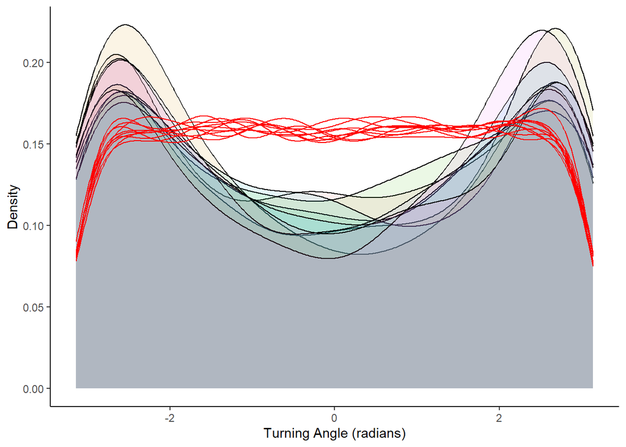

```r
ggplot() +
  geom_density(data = ssf_data_all %>% filter(y == 1),
               aes(x = ta_, fill = idf),
               alpha = 0.1, show.legend = F) +
  # plot a red line for each individual - which should all be similar as they were sampling from the same distribution
  geom_density(data = ssf_data_all %>% filter(y == 0),
               aes(x = ta_, group = idf),
               colour = "red", alpha = 0.1, show.legend = F) +
  scale_x_continuous(name = "Turning Angle (radians)") +
  scale_y_continuous(name = "Density") +
  theme_classic()
```

```r
# to save the plot
# ggsave("TurningAngleDsitribution-used.png", width=150, height=90, units="mm", dpi = 300)
```

### Prepare data to save to file

```r
# check for NAs in the turning angles
sum(is.na(ssf_data_all$ta_))
```

```
[1] 6
```

```r
# removes rows with NAs
ssf_data_all <- ssf_data_all %>% filter(!is.na(cos_ta_))
```

INLA requires that we have a different ID column for each covariate, so we will create some here (we can always create more later).

```r
ssf_data_all <- ssf_data_all %>%
  mutate(id_num = as.numeric(factor(id)),
         step_id = paste(id, step_id_, sep = "-"))

ssf_data_all$id1 <- ssf_data_all$id_num
ssf_data_all$id2 <- ssf_data_all$id_num
ssf_data_all$id3 <- ssf_data_all$id_num
ssf_data_all$id4 <- ssf_data_all$id_num
ssf_data_all$id5 <- ssf_data_all$id_num
ssf_data_all$id6 <- ssf_data_all$id_num
ssf_data_all$id7 <- ssf_data_all$id_num
ssf_data_all$id8 <- ssf_data_all$id_num
ssf_data_all$id9 <- ssf_data_all$id_num
```

# Save the data

We can save this dataset and use it for both the individual-level and population-level SSFs.

```r
write_csv(ssf_data_all, paste0("outputs/data_SSF_ready_", Sys.Date(), ".csv"))
```

### References

Michelot, Théo, Natasha J Klappstein, Jonathan R Potts, and John Fieberg. 2024. “Understanding Step Selection Analysis Through Numerical Integration.” *Methods in Ecology and Evolution* 15 (1): 24–35. https://doi.org/10.1111/2041-210x.14248.

Signer, Johannes, John Fieberg, and Tal Avgar. 2019. “Animal Movement Tools (Amt): R Package for Managing Tracking Data and Conducting Habitat Selection Analyses.” *Ecology and Evolution* 9 (2): 880–90. https://doi.org/10.1002/ece3.4823.